# When did ‘Happy Days’ really jump the shark?

[Back to Home Page](http://velavar.github.io/)

Some time back I came across [this analysis](https://www.r-bloggers.com/when-did-how-i-met-your-mother-become-less-legen-wait-for-it) of when the series ‘How I met your mother’ possibly witnessed a downtrend in ratings. So of course I had to try it out on ‘Happy Days’ - the show that engendered the famous phrase - *jumping the shark* - used to describe TV series that have run their course and are on the wane popularity-wise.

First I copied the ratings on the show’s [IMDB ratings page](http://www.imdb.com/title/tt0070992/epdate?ref_=ttep_ql_4) into a *.csv* file and loaded the required libraries.

```r
library(changepoint)
library(ggplot2)
library(zoo)
```

```r
hd = read.csv("happydays-ratings.csv")
```

Next I use the *changepoint* package in R to detect a breakpoint in the trend in ratings. I don’t specify the number of breakpoints so as to let the algorithm discover it on its own, but as it turns out, there was only one breakpoint anyway. Plotting the ratings shows the breakpoint to exist somewhere around the episode #165 - nowhere close to the accused episode that featured Fonzie jumping over the shark (Season 5 - Episode 3 (Overall episode #91)).

```r
mean2.pelt = cpt.mean(hd$Rating, method="PELT")
```

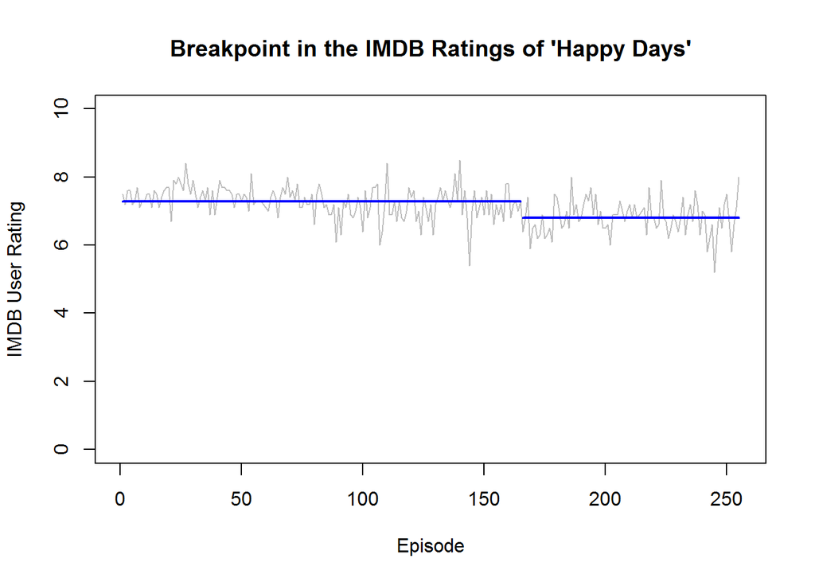

```r
cpts(mean2.pelt)
```

```
## [1] 165
```

The drop itself isn’t very significant and hardly resembles the steep wane in popularity that the phrase “jumping the shark” has come to represent. If the user-ratings on IMDb are anything to go by, the show remained popular well after the *jumping-the-shark* act.